# INFORME DE ESTADÍSTICA Y PROBABILIDADES

Título del proyecto:

# **LA SILLA IDEAL PARA UN ESTUDIANTE DE UTEC**

Título corto: **LaSillaIdealUTEC**

## Cargar Datos

```r
library(readr)
library(dplyr)
library(modeest)
library(tidyverse)
```

```r
library(ggplot2)

library(stringr)

library(mixtools)
DFN<-read_csv("Encuesta.csv")
names(DFN)
```

```
##  [1] "Marca temporal"
##  [2] "Dirección de correo electrónico"
##  [3] "¿Cuál es tu código de estudiante?"
##  [4] "Indica tu sexo"
##  [5] "¿Del 1 al 5 qué tan cómodo te sientes con la silla que usas para tus clases virtuales?"
##  [6] "¿Del 1 al 5 qué tan concentrado estás durante tus clases virtuales?"
##  [7] "¿Cuál es tu estatura? Por favor introduce tu estatura en centímetros (cm) Ejemplo: 163"
##  [8] "¿Cuál es tu peso? Por favor introduce tu peso en kilogramos (kg) Ejemplo: 62.5"
##  [9] "¿Te gusta que las sillas tengan ruedas?"
## [10] "¿Te gustan las sillas acolchadas?"
## [11] "¿Te gustaría un soporte lumbar en tu silla?"
## [12] "¿Te gustaría una silla que tenga reposabrazos?"
## [13] "¿Te gustaría que tu silla tenga un asiento regulable?"
## [14] "Si marcaste sí en la pregunta anterior, ¿Cuánto te gustaría que se pueda regular la altura de tu silla (cm)?"
## [15] "¿Cómo prefieres que estén tus pies al sentarte?"
## [16] "¿Te gustaría que tu silla se pueda reclinar?"
## [17] "Si marcaste sí en la pregunta anterior, ¿Cuánto te gustaría que tu silla se pueda reclinar?"
## [18] "¿Cuántas horas diarias pasas sentado al estudiar?"
## [19] "¿Qué material para el tapizado de tu silla te gustaría que tuviera?"
## [20] "Con todas las características que has elegido para tu silla ideal, ¿Cuál sería tu nuevo nivel de comodidad usando la silla?"
## [21] "¿Cuánto estarías dispuesto a pagar por la silla?  El precio está considerado en soles"
## [22] "Con todas las características que has elegido para tu silla ideal, ¿Cuál sería tu nuevo nivel de concentración usando la silla?"
```

```r
DFN-> DF
```

```r
#Cambiando nombres
DF %>% rename(Sexo= `Indica tu sexo`) -> DF
DF %>% rename(Email= `Dirección de correo electrónico`) -> DF
DF %>% rename(Codigo= `¿Cuál es tu código de estudiante?`) -> DF
DF %>% rename(Comodidad=`¿Del 1 al 5 qué tan cómodo te sientes con la silla que usas para tus clases virtuales?`) -> DF
DF %>% rename(Concentracion= `¿Del 1 al 5 qué tan concentrado estás durante tus clases virtuales?`) -> DF
DF %>% rename(Estatura= `¿Cuál es tu estatura? Por favor introduce tu estatura en centímetros (cm) Ejemplo: 163`) -> DF
DF %>% rename(Peso= `¿Cuál es tu peso? Por favor introduce tu peso en kilogramos (kg) Ejemplo: 62.5`) -> DF
DF %>% rename(Ruedas=`¿Te gusta que las sillas tengan ruedas?`) -> DF
DF %>% rename(Acolchonado=`¿Te gustan las sillas acolchadas?`) -> DF
DF %>% rename(SoporteLumbar= `¿Te gustaría un soporte lumbar en tu silla?`) -> DF
DF %>% rename(AsientoRegulable= `¿Te gustaría que tu silla tenga un asiento regulable?`) -> DF
DF %>% rename(Regulacion=`Si marcaste sí en la pregunta anterior, ¿Cuánto te gustaría que se pueda regular la altura de tu silla (cm)?`) -> DF
DF %>% rename(PosPies= `¿Cómo prefieres que estén tus pies al sentarte?`) -> DF
DF %>% rename(AsientoReclinable= `¿Te gustaría que tu silla se pueda reclinar?`) -> DF
DF %>% rename(Reclinacion= `Si marcaste sí en la pregunta anterior, ¿Cuánto te gustaría que tu silla se pueda reclinar?`) -> DF
DF %>% rename(HorasEstudio= `¿Cuántas horas diarias pasas sentado al estudiar?`) -> DF
DF %>% rename(Material= `¿Qué material para el tapizado de tu silla te gustaría que tuviera?`) -> DF
DF %>% rename(NewComodidad= `Con todas las características que has elegido para tu silla ideal, ¿Cuál sería tu nuevo nivel de comodidad usando la silla?`) -> DF
DF %>% rename(Presupuesto= `¿Cuánto estarías dispuesto a pagar por la silla?  El precio está considerado en soles`) -> DF
DF %>% rename(Reposabrazo=`¿Te gustaría una silla que tenga reposabrazos?`) -> DF
DF %>% rename(NewConcentracion=`Con todas las características que has elegido para tu silla ideal, ¿Cuál sería tu nuevo nivel de concentración usando la silla?`) -> DF
DF %>% rename(Marca=`Marca temporal`) ->DF
```

```r
#Verificando
summary(DF)
```

```
##     Marca              Email               Codigo              Sexo
##  Length:246         Length:246         Min.   :     2019   Length:246
##  Class :character   Class :character   1st Qu.:201910273   Class :character
##  Mode  :character   Mode  :character   Median :202010296   Mode  :character
##                                        Mean   :200411056
##                                        3rd Qu.:202020049
##                                        Max.   :202119507
##
##    Comodidad     Concentracion    Estatura          Peso
##  Min.   :1.000   Min.   :1     Min.   :  1.5   Min.   : 44.00
##  1st Qu.:2.000   1st Qu.:3     1st Qu.:160.0   1st Qu.: 57.00
##  Median :3.000   Median :3     Median :167.0   Median : 62.40
##  Mean   :3.171   Mean   :3     Mean   :152.3   Mean   : 64.16
##  3rd Qu.:4.000   3rd Qu.:4     3rd Qu.:174.0   3rd Qu.: 70.00
##  Max.   :5.000   Max.   :5     Max.   :189.0   Max.   :100.00
##
##     Ruedas          Acolchonado        SoporteLumbar      Reposabrazo
##  Length:246         Length:246         Length:246         Length:246
##  Class :character   Class :character   Class :character   Class :character
##  Mode  :character   Mode  :character   Mode  :character   Mode  :character
##
##
##
##
##  AsientoRegulable     Regulacion      PosPies          AsientoReclinable
##  Length:246         Min.   : 5.00   Length:246         Length:246
##  Class :character   1st Qu.:10.00   Class :character   Class :character
##  Mode  :character   Median :15.00   Mode  :character   Mode  :character
##                     Mean   :14.11
##                     3rd Qu.:20.00
##                     Max.   :20.00
##                     NA's   :16
##  Reclinacion         HorasEstudio      Material          NewComodidad
##  Length:246         Min.   : 1.000   Length:246         Min.   :2.000
##  Class :character   1st Qu.: 6.000   Class :character   1st Qu.:5.000
##  Mode  :character   Median : 8.000   Mode  :character   Median :5.000
##                     Mean   : 8.484                      Mean   :4.768
##                     3rd Qu.:10.000                      3rd Qu.:5.000
##                     Max.   :14.000                      Max.   :5.000
##
##   Presupuesto     NewConcentracion
##  Min.   : 350.0   Min.   :1.000
##  1st Qu.: 400.0   1st Qu.:4.000
##  Median : 500.0   Median :4.000
##  Mean   : 528.3   Mean   :4.211
##  3rd Qu.: 600.0   3rd Qu.:5.000
##  Max.   :1000.0   Max.   :5.000
##
```

```r
#Datos irregulares a NA
table(DF$Peso)
```

```
##
##   44   45 45.5   46   48   49 49.5   50   51 51.8   52 52.5   53 53.5   54   55
##    1    1    1    2    2    1    1    6    1    1    6    1    9    1   10    9
## 55.4   56 56.5 56.7   57 57.4   58 58.5   59   60   61   62 62.4 62.5   63   64
##    1    3    1    1   10    1    9    1    8   21    6    7    2    2    8    7
## 64.3 64.4   65 65.4 65.7   66   67 67.2   68   69   70   71   72   73 73.5   74
##    1    1   15    1    1    3    3    1    9    2    9    1    8    3    1    1
##   75   76 76.5   77   78 78.7   79 79.5   80   81 81.5   82   83   84   85   88
##    7    3    1    2    6    1    2    1    4    1    1    1    3    1    5    1
##   90   95   99  100
##    1    2    1    1
```

```r
table(DF$Estatura)
```

```
##
##   1.5  1.52  1.55  1.56  1.58   1.6  1.61  1.65  1.68  1.69   1.7  1.75  1.78
##     1     1     1     1     1     6     1     1     2     1     1     2     1
##  1.79   1.8   150   152   153   154   155   156 156.5   157   158   159   160
##     1     2     5     1     6     4     2     3     1     2     5     4    11
##   161   162   163   164   165   166   167   168   169   170   171   172   173
##     3     7    13     7    19     5     5    11     7    20     8     5     5
##   174   175   176   177   178   179   180   181   183   184   187   189
##     9    18     8     4     4     4     6     3     3     3     1     1
```

```r
#Solo en estatura hay datos irregulares imposibles: 1.5, 1.52, 1.55 1.56, 1.58, 1.6, 1.65, 1.68, 1.75, 1.8
```

```r
table(DF$Reclinacion)
```

```
##
## 120° 165° 180°  90°
##   86   60   70    5
```

```r
#todos los ángulos están forma de letras
```

```r
#Corrigiendo datos irregulares
DF$Material[DF$Material=="Cuero sintético"]<-"Cuero sint."
DF$Estatura[DF$Estatura==1.50]<- 150
DF$Estatura[DF$Estatura==1.52]<- 152
DF$Estatura[DF$Estatura==1.55]<- 155
DF$Estatura[DF$Estatura==1.56]<- 156
DF$Estatura[DF$Estatura==1.58]<- 158
DF$Estatura[DF$Estatura==1.60]<- 160
DF$Estatura[DF$Estatura==1.61]<- 161
DF$Estatura[DF$Estatura==1.65]<- 165
DF$Estatura[DF$Estatura==1.68]<- 168
DF$Estatura[DF$Estatura==1.69]<- 169
DF$Estatura[DF$Estatura==1.70]<- 170
DF$Estatura[DF$Estatura==1.75]<- 175
DF$Estatura[DF$Estatura==1.78]<- 178
DF$Estatura[DF$Estatura==1.79]<- 179
DF$Estatura[DF$Estatura==1.80]<- 180
#Cambiando datos que deberían ser numéricos a numéricos
DF$Reclinacion[DF$Reclinacion=="120°"]<- 120
DF$Reclinacion[DF$Reclinacion=="165°"]<- 165
DF$Reclinacion[DF$Reclinacion=="180°"]<- 180
DF$Reclinacion[DF$Reclinacion=="90°"]<- 90
DF$Reclinacion<-as.numeric(DF$Reclinacion)

a<-str_split_fixed(str_split_fixed(DF$Marca, "\\s", 2)[,1], "\\/",3)
DF$Marca<-as.numeric(str_c(a[,3],a[,2],ifelse(str_length(a[,1])==2,"","0"),a[,1]))
DF$Codigo<-str_sub(as.character(DF$Codigo), start = 1, end = 4)
```

```r
#Verificando
table(DF$Estatura)
```

```
##
##   150   152   153   154   155   156 156.5   157   158   159   160   161   162
##     6     2     6     4     3     4     1     2     6     4    17     4     7
##   163   164   165   166   167   168   169   170   171   172   173   174   175
##    13     7    20     5     5    13     8    21     8     5     5     9    20
##   176   177   178   179   180   181   183   184   187   189
##     8     4     5     5     8     3     3     3     1     1
```

```r
table(DF$Reclinacion)
```

```
##
##  90 120 165 180
##   5  86  60  70
```

##### **¿Cómo se fomentó la representatividad de la muestra?**

La representatividad de la muestra radica en que la encuesta fué distribuida a estudiantes de diferentes ciclos en prácticamente la misma proporción, por ello podemos encontrar encuestados con códigos de alumno con 4 cifras iniciales entre 2017 hasta 2021, que representa el año en que ingresaron a la universidad.

Número de observaciones totales

```r
nrow(DF)
```

```
## [1] 246
```

Observaciones incompletas:

```r
sum(is.na(DF))
```

```
## [1] 41
```

El número observaciones incompletas se debe a que los encuestados no querían tener un ángulo de reclinación o tampoco querían una altura de regulación en sus asientos, lo cual repercute en las variables (Regulacion) y (Reclinacion), mismas que nos ayudan a saber la cantidad de estudiantes que prefiere o no estas características.

Nombres de las variables en el Data Frame:

```r
names(DF)
```

```
##  [1] "Marca"             "Email"             "Codigo"
##  [4] "Sexo"              "Comodidad"         "Concentracion"
##  [7] "Estatura"          "Peso"              "Ruedas"
## [10] "Acolchonado"       "SoporteLumbar"     "Reposabrazo"
## [13] "AsientoRegulable"  "Regulacion"        "PosPies"
## [16] "AsientoReclinable" "Reclinacion"       "HorasEstudio"
## [19] "Material"          "NewComodidad"      "Presupuesto"
## [22] "NewConcentracion"
```

# **INTRODUCCIÓN**

La trascendencia del proyecto “La silla ideal para un estudiante de UTEC” se encuentra en nuestra intención de poner a prueba la hipótesis de que debido a la coyuntura actual, los estudiantes estarían más interesados en mejorar su nivel de comodidad desde sus hogares, pues permanecen horas sentados frente a un escritorio para llevar a cabo sus clases de manera virtual; por ende, es probable que le otorguen ahora mayor importancia a las características de sus sillas. A diferencia de las clases presenciales, en esta nueva normalidad podemos asistir a un mayor número de clases por día al alcance de un par de clics, es decir, nos mantenemos sentados por períodos más extensos de tiempo. Además, podemos afirmar que el tema de este proyecto es innovador porque analizaremos si es posible que un conjunto de características de una silla sea considerado como un factor que contribuiría de manera positiva o negativa en la concentración de los estudiantes de UTEC. Del mismo modo, con este estudio podremos proporcionar una base de datos y un análisis estadístico que puede ser de gran interés para aquellos negocios que pertenezcan al rubro de fabricación y venta de sillas porque podrán adquirir insights de su público objetivo.Finalmente, la ejecución de este proyecto será posible ya que contamos con tres herramientas esenciales para llevar a cabo este proyecto. En primer lugar, para recopilar datos y crear nuestra base de datos de forma remota utilizaremos las encuestas de Google Forms. En segundo lugar, contamos con un software con el que podremos limpiar y procesar la información, del mismo modo podremos crear una gran variedad de gráficos para presentar los datos. En último lugar, estamos empleando una página web llamada Sci-Hub que nos permite acceder a millones de papers de investigación, logrando que no se restrinja nuestra búsqueda de información y argumentos que puedan respaldar este proyecto.

# **OBJETIVOS**

- **Objetivo principal:** Obtener parámetros para la elaboración de una silla ergonómica que puedan influir en la concentración de los estudiantes de UTEC.
- **Objetivos específicos:**
  - Determinar los criterios que influyen en el nivel de comodidad de una silla
  - Evidenciar una relación entre el nivel de comodidad y concentración de los estudiantes dentro de la modalidad de enseñanza virtual
  - Ejecutar un estudio estadístico que sea de interés a empresas proveedoras de sillas

**PREGUNTAS DE INTERÉS**

- ¿Existe una relación entre la comodidad y la concentración de los estudiantes en las clases?
  - ¿De qué modo repercute la comodidad de una silla respecto a la eficiencia del estudiante en sus clases?
- ¿Qué aspectos se deben tener en cuenta para la elaboración de sillas?
  - ¿Cómo se relaciona la estatura de una persona con el largo del espaldar de una silla para proporcionar comodidad?
  - ¿De qué forma influye la inclinación, altura y largo del espaldar de una silla en la comodidad de un estudiante?
- ¿El sexo del estudiante marcará una tendencia diferente sobre las preferencias por un tipo de silla?

# **MARCO TEÓRICO**

**POBLACIÓN OBJETIVO:** El grupo de personas sobre las que realizaremos el estudio estadístico son los estudiantes de UTEC.

**UNIDAD MUESTRAL:** En la encuesta realizada a los estudiantes de UTEC, la unidad muestral es por personas, que posteriormente serán clasificados por género.

**TIPO DE MUESTREO:** Por conveniencia.

**VARIABLES CON SU CLASIFICACIÓN:**

**Variables**

**Tipo de variable**

**Restricciones**

- Horas diarias que pasa sentado frente a su ordenador/laptop al día

Numérica discreta

Entero no negativo (1-14 horas)

- Estatura de la persona (cm)

Numérica continua

Entero positivo (cm)

Largo del espaldar de la silla (cm)

Numérica discreta

Entero positivo (cm)

- Reclinación

Numérica discreta

Ángulos entre: 90°, 120°,165° y 180°

- Precio que están dispuestos a pagar (soles)

Numérica discreta

Entero positivo(soles) 50k; k $\in$[7,20]

- Material de la silla

Categórica nominal

-Cuero natural -Terciopelo -Cuero sintético -Algodón -Plástico

- Preferencia por las sillas con o sin ruedas

Categórica nominal

Booleano (Sí o No)

- Preferencia por las sillas acolchadas o no acolchadas

Categórica nominal

Booleano (Sí o No)

- Preferencia por silla con o sin reposabrazos

Categórica nominal

Booleano (Sí o No)

Rango de regulación de la altura del asiento de la silla

Numérica continua

Entero positivo, rango: (15,20,10,5)en cm

- Preferencia por asientos regulables

Categórica nominal

Booleano (Sí o No)

Profundidad del asiento

Numérica discreta

Entero positivo (cm)

Ancho del asiento

Numérica discreta

Entero positivo (cm)

- Peso

Numérica continua

Real positivo (kg)

Índice de masa corporal (IMC)

Numérica continua

Real positivo (kg/m)

- Preferencia por la inclusión de un soporte lumbar en la silla

Categórica nominal

Booleano (Sí o No)

- Comodidad antes y después

Categórica ordinal

Escala de Likert, Rango: entre 1 al 5

- Concentración antes y después

Categórica ordinal

Escala de Likert, Rango: entre 1 al 5

- Sexo

Categórica nominal

Femenino o Masculino

- Posición

Categórica nominal

Pies tocando el suelo o sin tocar el suelo

### **Preguntas para las variables**

- ¿Cuál es tu sexo? $\Rightarrow$ Variable **sexo**
- ¿Del 1 al 5 qué tan cómodo te sientes con la silla que usas para tus clases virtuales? $\Rightarrow$ Variable **comodidad**
- ¿Del 1 al 5 qué tan concentrado estás durante tus clases virtuales? $\Rightarrow$ Variable **concentración**
- ¿Cuál es tu estatura en cm? $\Rightarrow$ Variable **estatura**
- ¿Cuál es tu peso en kg? $\Rightarrow$ Variable **peso**
- ¿Te gusta que las sillas tengan ruedas? $\Rightarrow$ Variable **preferencia por las sillas con o sin ruedas**
- ¿Te gustan las sillas acolchadas? $\Rightarrow$ Variable **preferencia por las sillas acolchadas o no acolchadas**
- ¿Te gustaría un soporte lumbar en tu silla? $\Rightarrow$ Variable **preferencia por la inclusión de un soporte lumbar en la silla**
- ¿Te gustaría una silla que tenga reposabrazos? $\Rightarrow$ Variable **preferencia por silla con o sin reposabrazos**
- ¿Te gustaría que tu silla tenga un asiento regulable? $\Rightarrow$ Variable **preferencia por asientos regulables**
- Si marcaste sí en la pregunta anterior, ¿Cuánto te gustaría que se pueda regular la altura de tu silla (cm)? $\Rightarrow$ Variable **rango de regulación de la altura del asiento de la silla**
- ¿Cómo prefieres que estén tus pies al sentarte? $\Rightarrow$ Variable **posición**
- ¿Te gustaría que tu silla se pueda reclinar? $\Rightarrow$ Variable **preferencia por asientos regulables**
- Si marcaste sí en la pregunta anterior, ¿Cuánto te gustaría que tu silla se pueda reclinar? $\Rightarrow$ Variable **reclinación**
- ¿Cuántas horas diarias pasas sentado al estudiar? $\Rightarrow$ Variable **horas diarias que pasa sentado frente a su ordenador/laptop al día**
- ¿Qué material para el tapizado de tu silla te gustaría que tuviera? $\Rightarrow$ Variable **material de la silla**
- Con todas las características que has elegido para tu silla ideal, ¿Cuál sería tu nuevo nivel de comodidad usando la silla? $\Rightarrow$ Variable **comodidad**
- Con todas las características que has elegido , ¿Cuál sería tu nuevo nivel de concentración? $\Rightarrow$ Variable **concentración**
- ¿Cuánto estarías dispuesto a pagar por la silla? $\Rightarrow$ Variable **precio**

### **Descriptores Numéricos**

- Descriptores numéricos para la variable regulación: Máximo, mínimo y moda.
- Descriptores numéricos para la variable peso: Máximo, mínimo, mediana, rango, IQR, promedio, desviación estándar y coeficiente de variación.
- Descriptores numéricos para la variable estatura: Máximo, mínimo, mediana, rango, IQR, promedio, moda, desviación estándar y coeficiente de variación.
- Descriptores numéricos para la variable ángulo: Máximo, mínimo, y moda.
- Descriptores numéricos para la variable horas: Máximo, mínimo, mediana, promedio, rango, moda y desviación estándar.
- Descriptores numéricos para la variable precio: Máximo, mínimo, mediana, moda, rango, IQR, promedio, desviación estándar y coeficiente de variación.

### **Descriptores Gráficos**

- Descriptor gráfico para la variable sexo: Barplot.
- Descriptor gráfico para la variable estatura: Histograma y boxplot.
- Descriptor gráfico para la variable peso: Histograma y boxplot.
- Descriptor gráfico para la variable regulación: Histograma.
- Descriptor gráfico para la variable ángulo: Histograma.
- Descriptor gráfico para la variable horas: Boxplot, histograma y diagrama de puntos.
- **Descriptor gráfico para las variables categóricas (dos variables): Barplot y mosaic plot.**

### **Factibilidad**

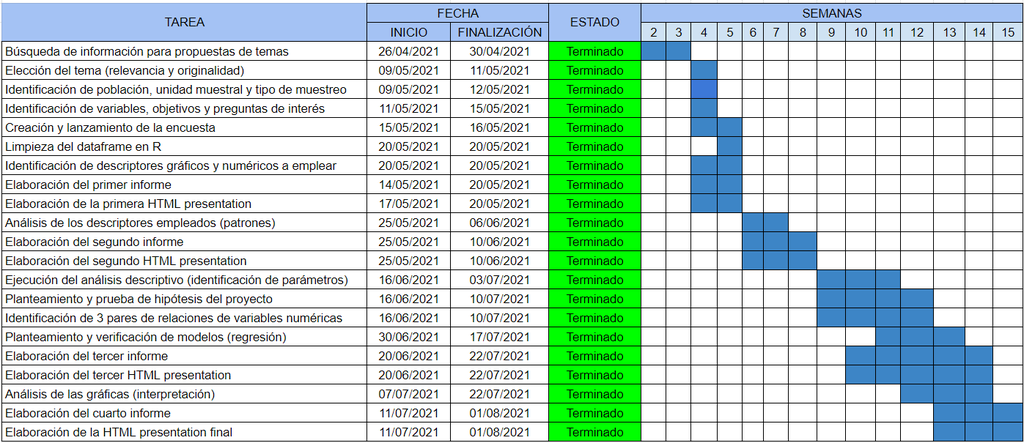

# **ANÁLISIS DESCRIPTIVO**

Se optó por solo usar el coeficiente de variación, el cual es una parametrización de la desviación estándar, por ello se puede comparar con los coeficientes de variación de otras variables. Misma razón por la cual se usará la correlación en lugar de la covarianza.

### **Encuestados**

$$\large
Comodidad\hspace{2pt}actual\hspace{2pt}\hspace{90pt}
Concentración\hspace{2pt} actual$$

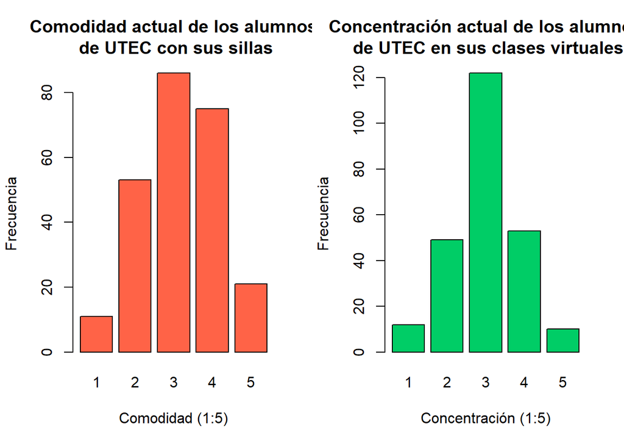

$$\left|\begin{array}{lcr}
-\hspace{2pt} Cómodos & Tranquilos & +\hspace{2pt}Cómodos
\\\hline
64 & 86 & 96 \\
\end{array}\right|\hspace{10pt}
\left|\begin{array}{lcr}
-\hspace{2pt}Concentrados & Tranquilos &
+\hspace{2pt}Concentrados \\\hline
61 & 122 & 63 \\
\end{array}\right|$$
Si bien es cierto que hay muchos más cómodos, concentrados y tranquilos, sigue existiendo un 26.02% de incómodos en sus sillas y un 24.8% con dificultad para concentrase. Como se observa en la siguiente tabla la correlación entre concentración y comodidad para las personas del sexo masculino y femenino es baja. Sin embargo, se aprecia que las personas del sexo femenino tienen cierta inclinación a estar menos cómodas y concentradas, caso contrario de las personas del sexo masculino.

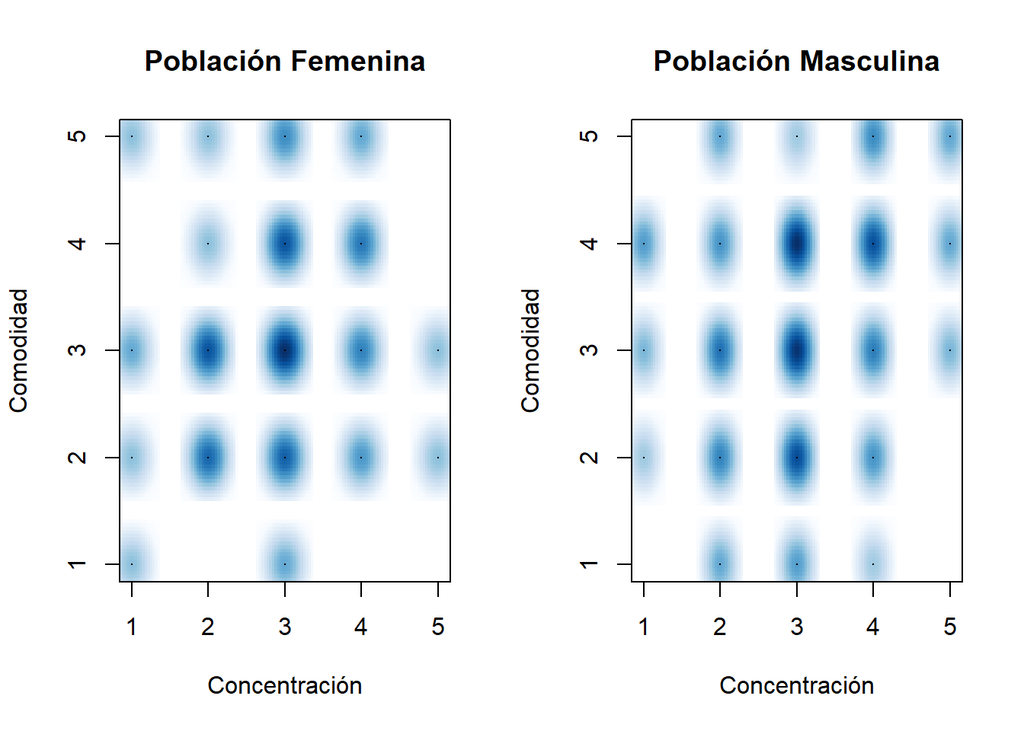

$$\left|\begin{array}{lcr}
Correlación \\\hline
0.17 \\
\end{array}\right|\hspace{90pt}
\left|\begin{array}{lcr}
Correlación \\\hline
0.23 \\
\end{array}\right|$$
Otra forma de visualizar relaciones es mediante el siguiente gráficos, en donde a pesar de que no hay una relación lineal, como se ve con las correlaciones, sí existe una, ya que dependiendo de la comodidad existe una distinta concentración.

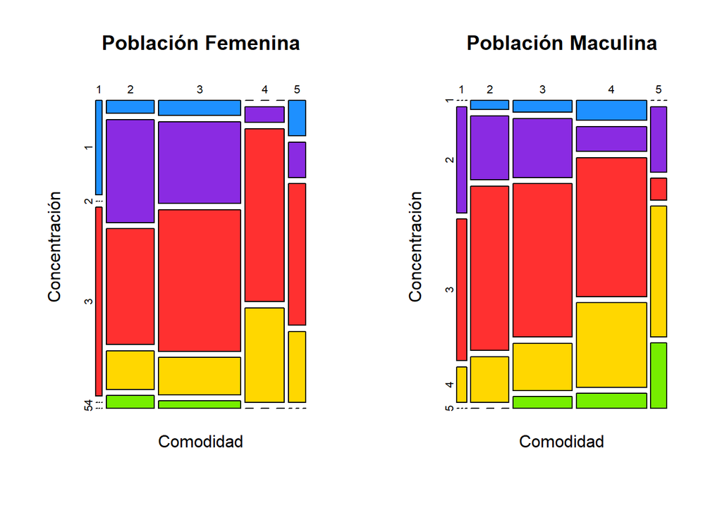

```r
op=par(mfrow=c(1,2))
mosaicplot(table(DF$Comodidad[DF$Sexo == "Femenino"], DF$Concentracion[DF$Sexo == "Femenino"]),ylab="Concentración",xlab="Comodidad",main="Población Femenina",col=c("dodgerblue1","blueviolet","firebrick1","gold1","chartreuse2"))
mosaicplot(table(DF$Comodidad[DF$Sexo == "Masculino"], DF$Concentracion[DF$Sexo == "Masculino"]),ylab="Concentración",xlab="Comodidad",main="Población Maculina",col=c("dodgerblue1","blueviolet","firebrick1","gold1","chartreuse2"))
```

```r
par(op)
```

Nota: Estos gráficos proporcionan la misma información que el anterior. Son solo 2 maneras de visualizar lo mismo.

Cabe destacar que el porcentaje común de estudiantes que se encuentran incómodos y con problemas para concentrarse, es del 8.54%. Al final, son estos porcentaje (incomodidad, concentración y la unión de ellos) y comportamiento lo que le da razón al estudio y son unas de las razones por las que continúa siendo significativo para la comunidad tanto de UTEC como para ciertos tipos de empresas.

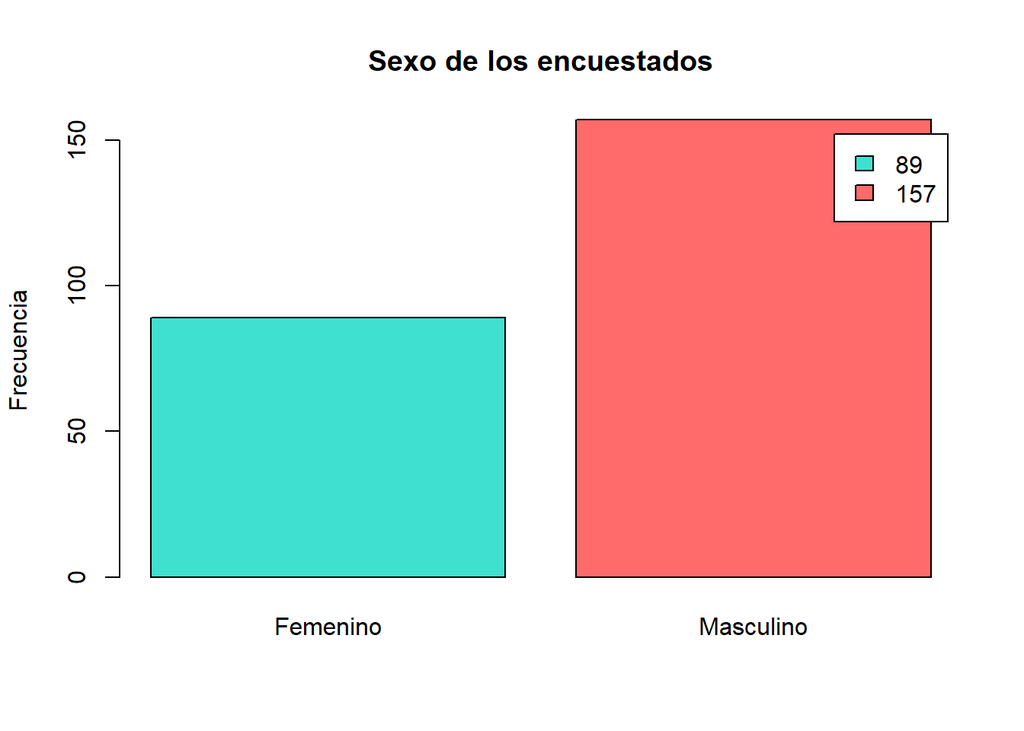

Se observa que entre los encuestados respondieron más personas del sexo masculino que del femenino, de acuerdo a nuestra hipótesis es probable que la universidad cuente con una población estudiantil masculina mayor a la población femenina, esto puede ser a causa de que sea una universidad de ingeniería.

#### **Peso de los encuestados (kg)**

```
## argument 'na.rm' is soft-deprecated, please start using 'na_rm' instead
```

#### **Descriptores Gráficos**

##### **Histograma**

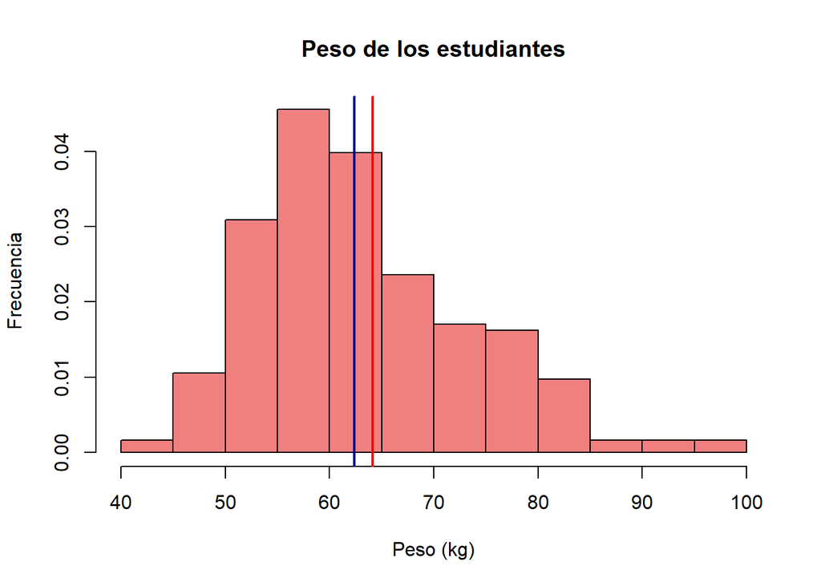

##### **Boxplot**

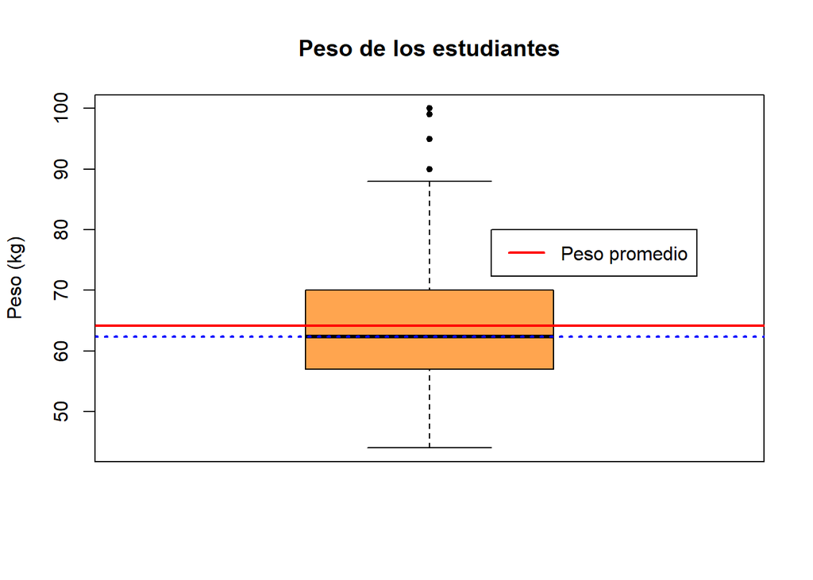

$$\textbf{Descriptores}\hspace{2pt}\textbf{Númericos}\\
\left|\begin{array}{lcr}
Rango & R.\hspace{2pt}Intercuartil & Moda & Mediana &
Media & Coeficiente\hspace{2pt}Var.\\\hline
valores\in [44,100] &valores\in [57,70]& 60 & 62.4 &
64.16 &0.16 \\
Rango= 56 & IQR = 13 & \\
\end{array}\right|$$

A partir de estos descriptores se puede observar, que generalmente los estudiantes de UTEC pesan 57 y 70 kilogramos, siendo el peso más común el de 60 kg. Por otro lado, el coeficiente de variación es relativamente bajo, esto significa que el peso de los estudiantes no varía mucho. Aún así, se aprecia que existe un sesgo a la derecha. Como se observa en el boxplot, hay presencia de valores atípicos, los cuales pertenecen a y son:

```r
head(DF[which(DF$Peso> q3+raint*1.5 | DF$Peso< q1-raint*1.5),which(names(DF)=="Peso" |names(DF)=="Codigo")])
```

| Codigo | Peso |
| --- | --- |
| 2018 | 99 |
| 2020 | 90 |
| 2020 | 100 |
| 2018 | 95 |
| 2019 | 95 |

#### **Estatura de los encuestados (cm)**

```
## argument 'na.rm' is soft-deprecated, please start using 'na_rm' instead
```

#### **Descriptores Gráficos**

##### **Histograma**

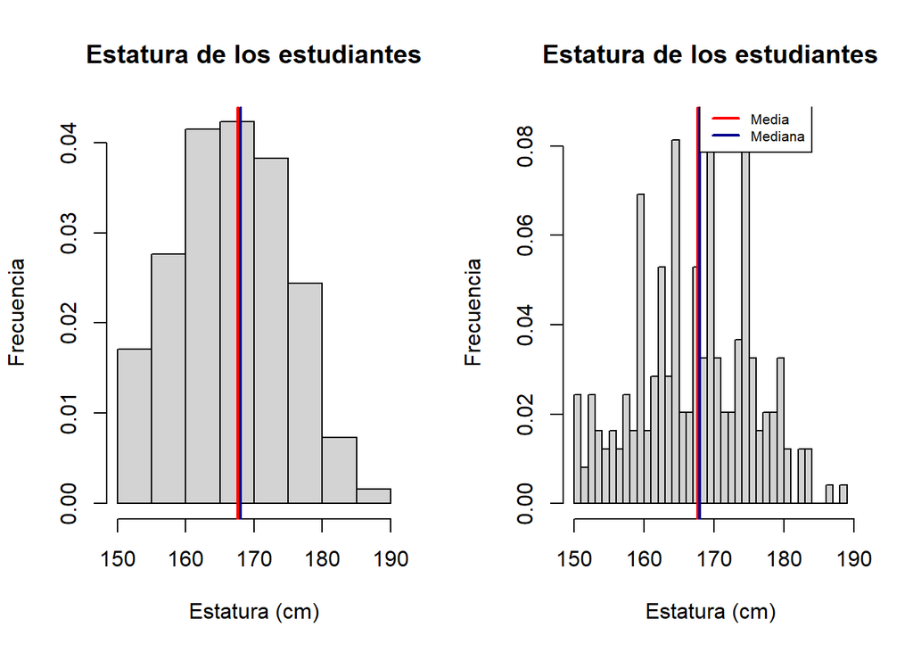

##### **Boxplot**

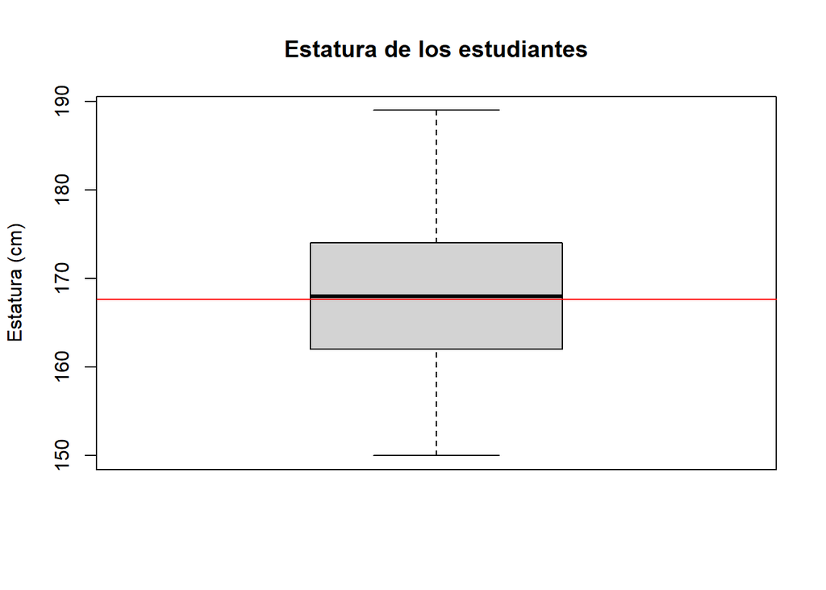

$$\textbf{Descriptores}\hspace{2pt}\textbf{Númericos}\\
\left|\begin{array}{lcr}
Rango & R.\hspace{2pt}Intercuartil & Moda & Mediana &
Media & Coeficiente\hspace{2pt}Var.\\\hline
valores\in [150,189] &valores\in [162,174]& 170 & 168 &
167.63 &0.05 \\
Rango= 39 & IQR = 12 & \\
\end{array}\right|$$

```r
Modas(DF$Estatura,"Estatura")
```

| Estatura | Cantidad |
| --- | --- |
| 160 | 17 |
| 163 | 13 |
| 165 | 20 |
| 168 | 13 |
| 170 | 21 |
| 175 | 20 |

Nota: los criterios usados para decir cuál era un valor común fue: a) repetición mínima de su valor igual a la mitad del más usual, y b) diferencia mínima de su repetición con el del valor mínimo relativo más cercano, igual a la mitad del máximo relativo a cuestionar como moda.

Sin embargo, las personas por lo general no se acuerdan su verdadera altura, por lo que escogen un valor cercano y que por lo general termina en 0 o 5. Claramente parece estar sucediendo eso. Así que, no hay que tomarlos como valores comunes, sino es preferible guiarse del histograma con menos clases así como del boxplot y los respectivos 1er y 3er cuartil. En donde, hay muchos estudiantes que se encuentran entre los 162 y 174 cm.

Por otro lado, con los valores de media, mediana y moda, el gráfico de las estaturas parecería ser simétrico en el intervalo de estaturas que presentan los estudiantes. Sin embargo, en lo observado del histograma, no parece tener estas características.

**Relación entre peso y estatura**

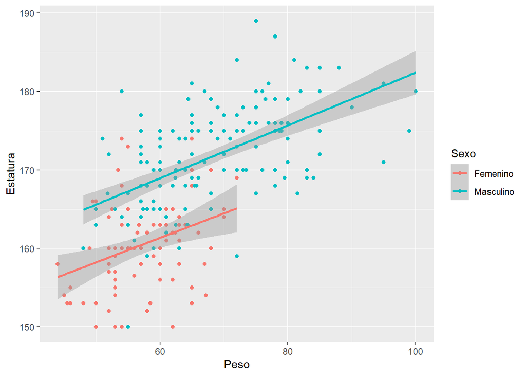

$$\left|\begin{array}{lcr}
Correlación\hspace{2pt} Femenina& Correlación\hspace{2pt}General
& Correlación\hspace{2pt}Masculina \\\hline
0.33 & 0.64&0.54\\
\end{array}\right|$$

Podemos observar que a mayor estatura del estudiante, estos tendrán un mayor peso. Se puede confirmar al ver la correlación, la existencia de una relación, aunque débil, entre estatura y peso para ambos sexos. Asimismo, entre la población de UTEC persiste una relación fuerte entre estas dos variables.

Estos datos nos servirán para estandarizar los tamaños de las sillas para cierta estatura y peso, de tal forma que las empresas que fabrican sillas, tengan mejores valores con los que trabajar.

##### **Variables con opciones reducidas**

Aunque las siguientes variables tuvieran opciones limitadas a la hora de la encuesta, en nuestra opinión, estas poseen una suficiente cantidad opciones (14) como para que descriptores tales como media, rango intercuartil, o coeficiente de variación sean considerados.

#### **Horas que pasan sentados estudiando los encuestados**

```
## argument 'na.rm' is soft-deprecated, please start using 'na_rm' instead
```

#### **Descriptores Gráficos**

##### **Histograma**

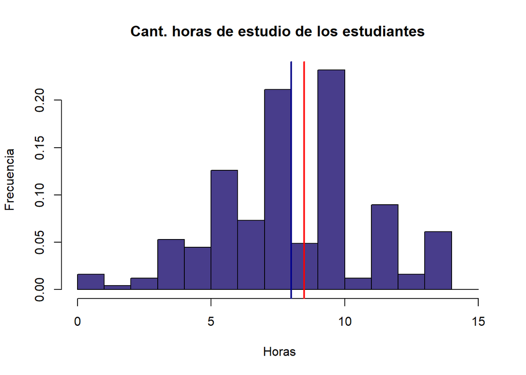

##### **Boxplot**

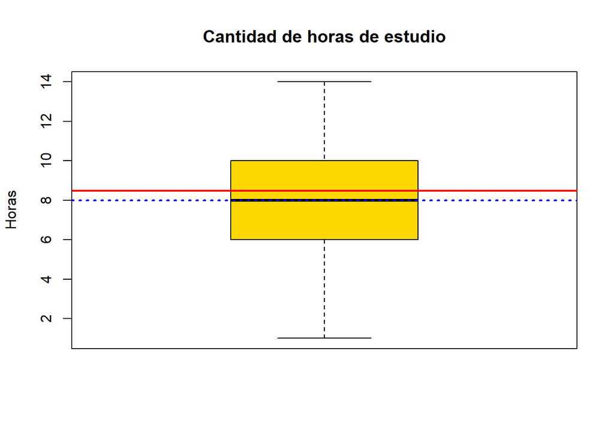

$$\textbf{Descriptores}\hspace{2pt}\textbf{Númericos}\\
\left|\begin{array}{lcr}
Rango & R.\hspace{2pt}Intercuartil & Moda & Mediana &
Media & Coeficiente\hspace{2pt}Var.\\\hline
valores\in [1,14] &valores\in [6,10]& 10 & 8 & 8.48
&0.33 \\
Rango= 13 & IQR = 4 & \\
\end{array}\right|$$

En promedio de 6 a 10 son las horas que los estudiantes pasan sentados estudiando, siendo 10 horas una cantidad común a escoger. Hay algunos que escogen estudiar hasta 14 horas y otros que estudian incluso solo 1 hora. En el caso de 14 horas puede parecer físicamente complicado, por ello invertir tanto tiempo sentado puede ocasionar problemas a la salud a largo plazo, por lo que no hay que hacer caso omiso.

#### **Presupuesto de los encuestados**

```
## argument 'na.rm' is soft-deprecated, please start using 'na_rm' instead
```

#### **Descriptores Gráficos**

##### **Histograma**

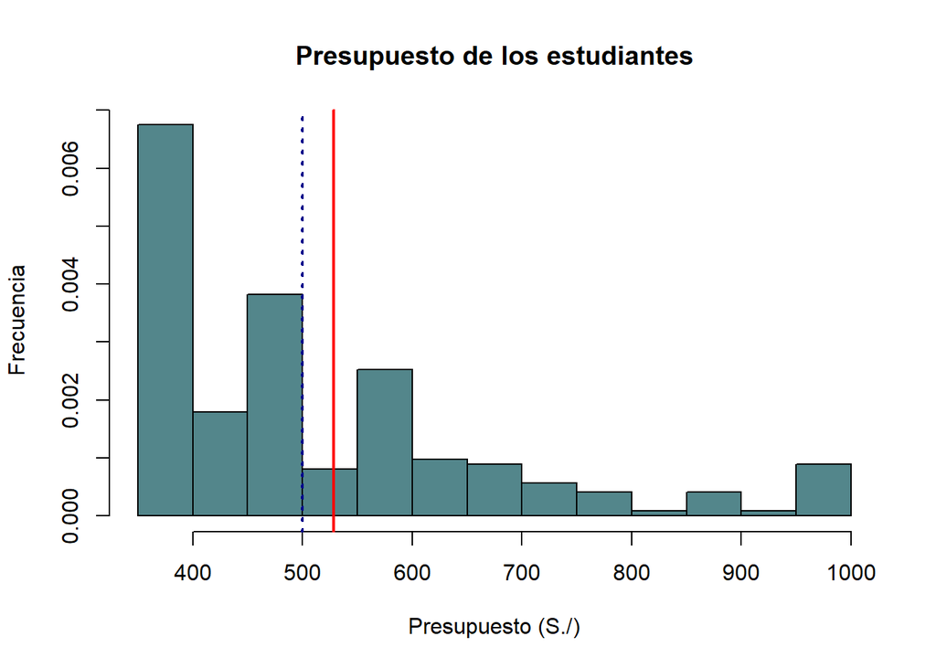

$$\textbf{Descriptores}\hspace{2pt}\textbf{Númericos}\\
\left|\begin{array}{lcr}
Rango & R.\hspace{2pt}Intercuartil & Moda & Mediana &
Media & Coeficiente\hspace{2pt}Var.\\\hline
valores\in [350,1000] &valores\in [400,600]& 350 & 500 &
528.25 &0.32 \\
Rango= 650 & IQR = 200 & \\
\end{array}\right|$$
Parece ser que una gran cantidad de alumnos escoge 350 como su presupuesto máximo. Esto bien podría ser debido a que no había opción más baja, los estudiantes hayan escogido la que más se les acomodase. Por otra parte, al menos la mitad de ellos, como se ve en el boxplot y el rango intercuartil, no haya escogido este precio, dada la posibilidad de que la UTEC tenga alumnos con mayores recursos a su disposición o que los estudiantes busquen algo de calidad y están dispuestos a pagarlo con sus ahorros.

##### **Boxplot**

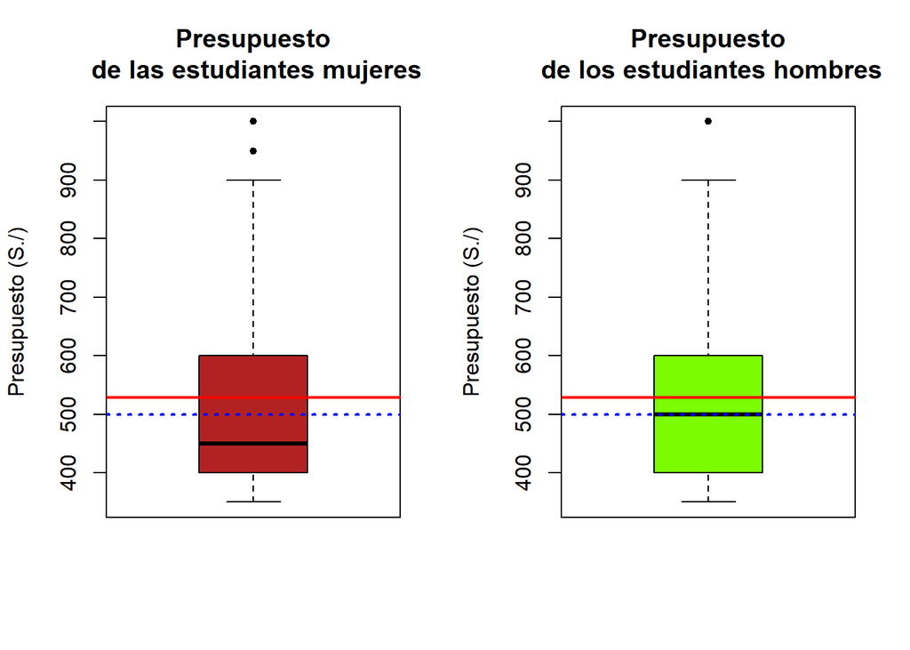

### **Características para la silla**

Se incluyeron cuatro variables categóricas, cada una de ellas con sus respectivas opciones en la encuesta, para analizarlas usaremos barplot. Asimismo, debido a la reducida cantidad de opciones (4) que tuvieron las variables numéricas de regulación y reclinación, también se las gráfico como si fueran categóricas, mediante barplots.

#### **Regulaciones**

$$\large
Regulación\hspace{2pt}de\hspace{2pt} la\hspace{2pt}altura\hspace{2pt}
(cm)\hspace{90pt} Reclinación\hspace{2pt} de\hspace{2pt} la\hspace{2pt}
silla\hspace{2pt} (°)$$

```
## argument 'na.rm' is soft-deprecated, please start using 'na_rm' instead
## argument 'na.rm' is soft-deprecated, please start using 'na_rm' instead
```

#### **Descriptores Gráficos**

##### **Barplot**

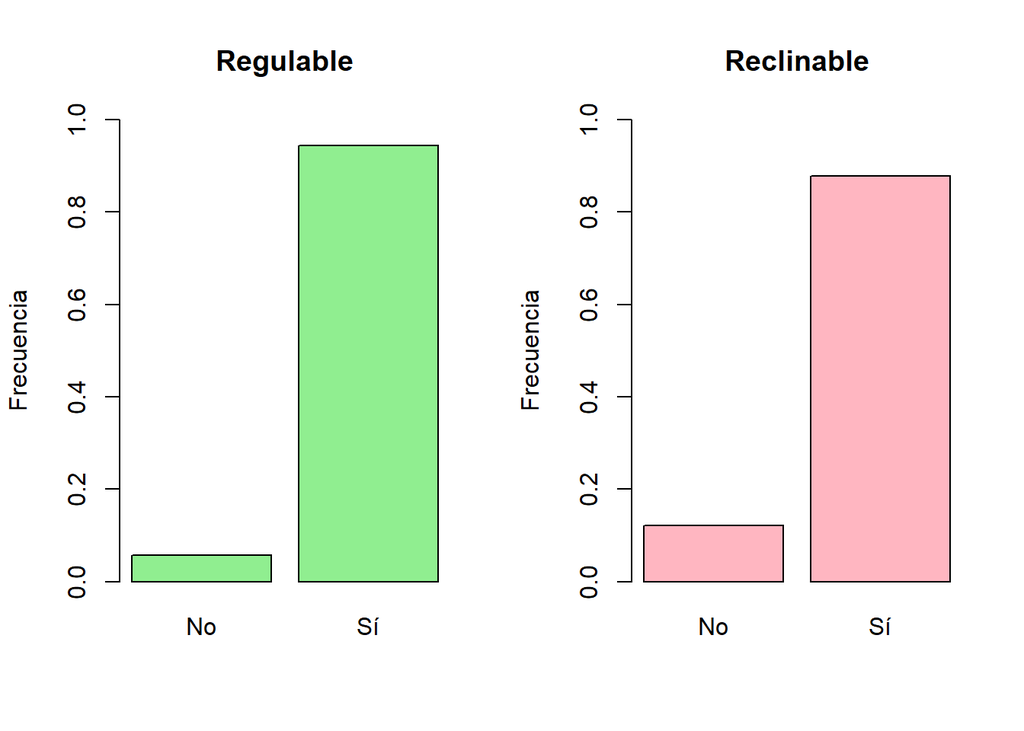

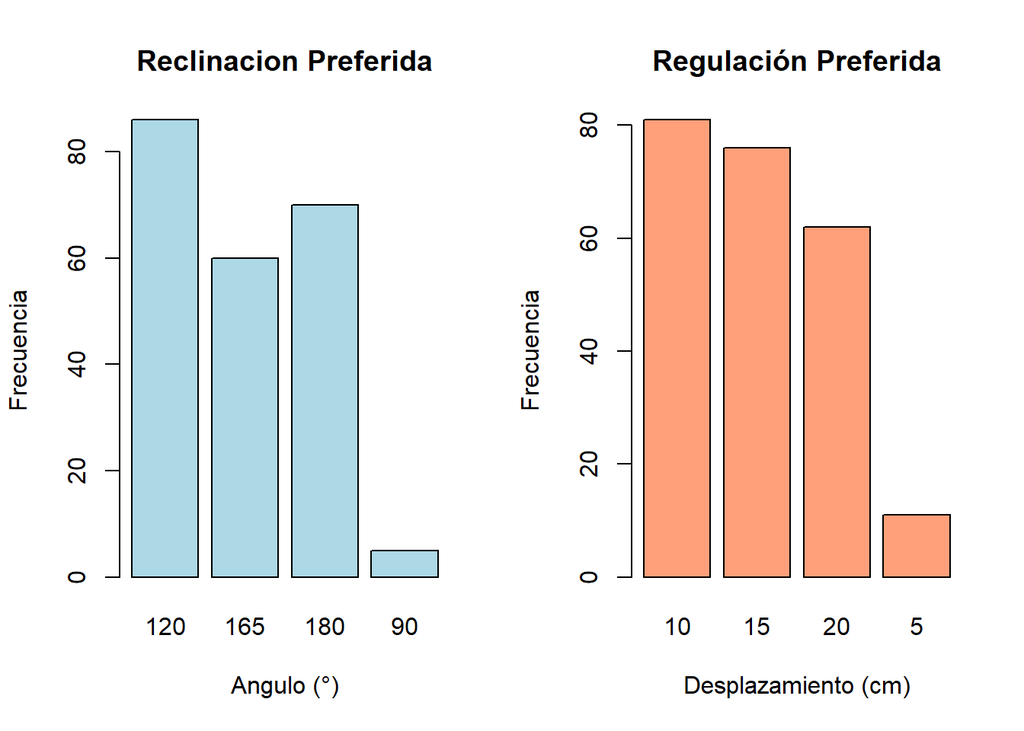

$$\textbf{Descriptores}\hspace{2pt}\textbf{Númericos}\hspace{64pt}\textbf{Descriptores}\hspace{2pt}\textbf{Númericos}\\
\left|\begin{array}{lcr}
Rango & Moda & Mediana \\\hline
valores\in [5,20] & 10 & 15 \\
Rango= 15 & & \\
\end{array}\right|
\left|\begin{array}{lcr}
Rango & Moda & Mediana \\\hline
valores\in [90,180] & 120 & 165 \\
Rango= 90 & & \\
\end{array}\right|$$

Como se puede ver en los gráficos, muchos de los estudiantes escogen poder regular y reclinar sus asientos. Sin embargo, cabe mencionar que los que escogieron que sí querían poder reclinar sus asientos, algunos optaron por una reclinación de (90°). Esto puede ser porque hubo una mala interpretación, ya que no es posible “reclinar” el asiento (90°) pues sería una posición normal.

Comprobando esto último:

```r
head(DF[which(DF$Reclinacion==90),which(names(DF)== "Codigo" | names(DF)== "AsientoReclinable" | names(DF)=="Reclinacion")])
```

| Codigo | AsientoReclinable | Reclinacion |
| --- | --- | --- |
| 2021 | No | 90 |
| 2021 | Sí | 90 |
| 2020 | Sí | 90 |
| 2020 | Sí | 90 |
| 2021 | Sí | 90 |

```r
head(DF[which(DF$AsientoReclinable=="No" & DF$Reclinacion%in%c(90,120,165,180)),which(names(DF)== "Codigo" | names(DF)== "AsientoReclinable" | names(DF)=="Reclinacion")])
```

| Codigo | AsientoReclinable | Reclinacion |
| --- | --- | --- |
| 2019 | No | 180 |
| 2020 | No | 180 |
| 2020 | No | 120 |
| 2021 | No | 90 |
| 2015 | No | 120 |

De igual manera, es mejor sustraer este posible error y asignarle a los valores NA para que no haya problemas en el futuro, al menos para los que marcaron “No”.

[figure not shown]

```r
DF$Reclinacion[which(DF$AsientoReclinable=="No" & DF$Reclinacion%in%c(90,120,165,180))]<-NA
DF$Regulacion[which(DF$AsientoRegulable=="No" & DF$Regulacion%in%c(5,10,15,20))]<-NA
```

$$\left|\begin{array}{lcr}
& No & Sí \\\hline
Femenino & 5 & 84 \\
Masculino& 9 & 148\\
\end{array}\right|\hspace{50pt}
\left|\begin{array}{lcr}
& No & Sí \\\hline
Femenino & 14 & 75 \\
Masculino&16 & 141\\
\end{array}\right|$$
Por último, se puede observar, que tanto las personas del sexo femenino como masculino prefieren asientos regulables. Es decir, la variable sexo no influye en la decisión para esta opción.

#### Accesorios para mayor comodidad

Son proporcionados para generar mayor comodidad:
$$\large Soporte\hspace{2pt}Lumbar\hspace{90pt}
Repozabrazos$$

#### **Descriptores Gráficos**

##### **Barplot**

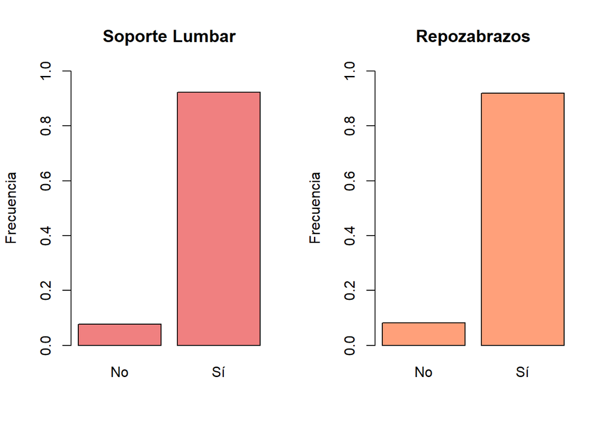

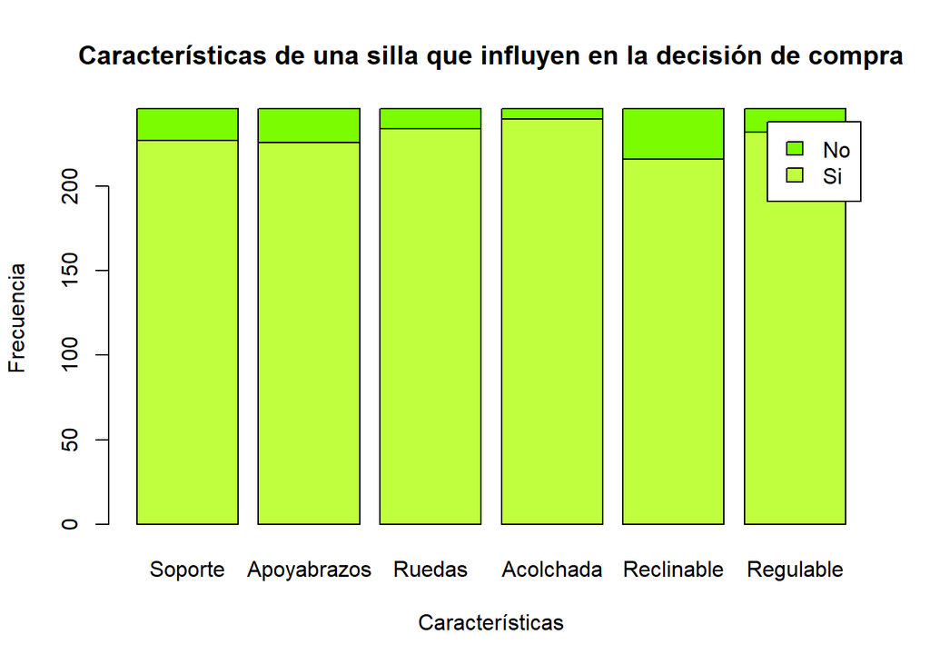

```r
binarios<-function(X){
  return(list(Si=sum(X=="Sí"),No=sum(X=="No")))
}
categoricas<-mapply(binarios,list(
  Soporte=DF$SoporteLumbar,
  Apoyabrazos=DF$Reposabrazo,
  Ruedas=DF$Ruedas,
  Acolchada=DF$Acolchonado,
  Reclinable=DF$AsientoReclinable,
  Regulable=DF$AsientoRegulable))

barplot(categoricas,col=c("olivedrab1","lawngreen"),legend.text=TRUE,main="Características de una silla que influyen en la decisión de compra",xlab="Características", ylab="Frecuencia")
```

Estas son algunas de las características de una silla y preferencias. Para un modelo de silla todas deberían ser incluidas en su diseño, pues son determinantes en el proceso de decisión de compra del estudiante, puesto que podría proporcionar mayor comodidad.

$$\left|\begin{array}{lcr}
Sí & No \\\hline
227 & 19 \\
\end{array}\right|\hspace{110pt}
\left|\begin{array}{lcr}
Sí & No \\\hline
226 & 20 \\
\end{array}\right|$$

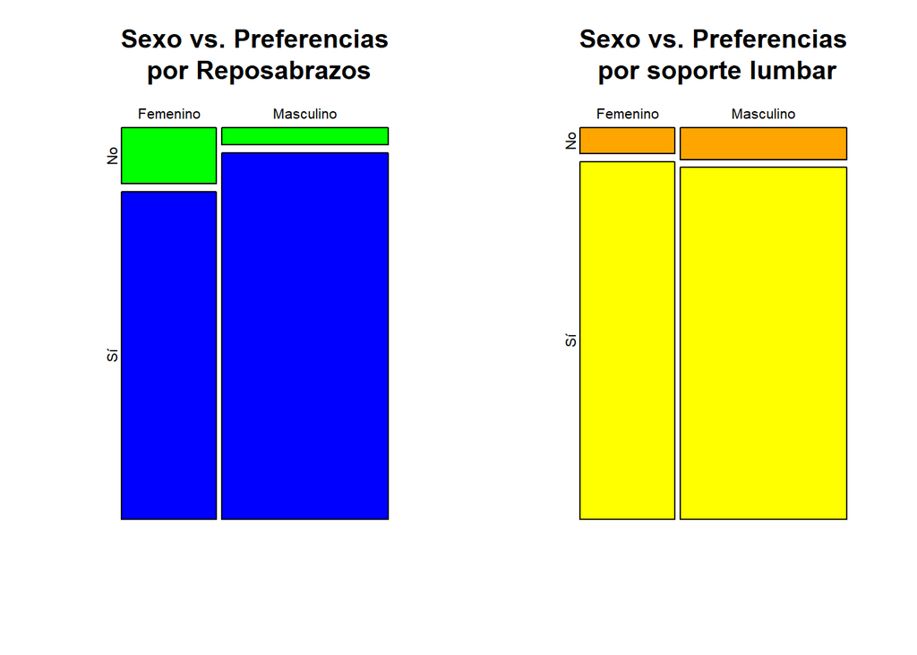

$$\left|\begin{array}{lcr}
& No & Sí \\\hline
Femenino & 13 & 76 \\
Masculino& 7 & 150\\
\end{array}\right|\hspace{50pt}
\left|\begin{array}{lcr}
& No & Sí \\\hline
Femenino & 6 & 83 \\
Masculino&13 & 144\\
\end{array}\right|$$
Con las preferencias por cada sexo, parece existir una pequeña tendencia porcentual en cuanto un grupo prefiere una opción, el otro no.

### **Algunas otras relaciones**

#### *Regulación y Posición de los pies*

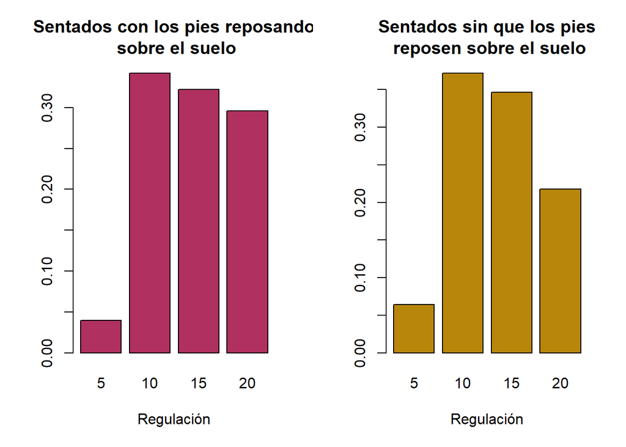

Hay una mayor cantidad de alumnos que prefieren tener una mayor regulación para sus sillas, una posible hipótesis sería que si los estudiantes prefieren regulación en sus sillas sea porque quieran estar sentados sin que sus pies reposen sobre el suelo y esto les proporcione mayor comodidad.

Por otro lado, originalmente se creía que si preferían que sus pies no reposen sobre el suelo hubiesen preferido una mayor regulación (desplazamiento vertical), lo cual no parece estar ocurriendo. Una nueva hipótesis, puede ser que haya menos estudiantes de alta estatura de los que escogieron que sus pies no estén reposando sobre el suelo, ya que estos son principalmente los que necesitan de un mayor desplazamiento para hacerlo.

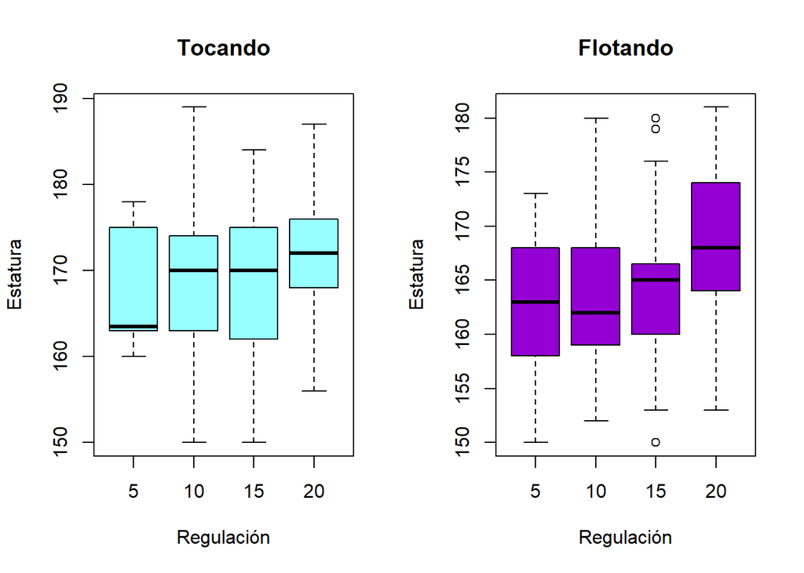

```r
op=par(mfrow=c(1,2))
boxplot(DF[which(DF$PosPies=="Tocando el suelo"),]$Estatura~DF[which(DF$PosPies=="Tocando el suelo"),]$Regulacion, main="Tocando", ylab="Estatura",xlab="Regulación",col="darkslategray1")
boxplot(DF[which(DF$PosPies=="Flotando"),]$Estatura~DF[which(DF$PosPies=="Flotando"),]$Regulacion, main="Flotando", ylab="Estatura",xlab="Regulación",col="darkviolet")
```

```r
par(op)
```

Como se puede apreciar en el boxplot a mayor estatura más tendrá que ser el desplazamiento necesario, si se quiere tener los pies sobre el suelo o no. Sin embargo, los que escogieron que la regulación sea de solo 5 cm fueron personas entre estaturas altas y medias. Al menos con esta población alta, podría ser que sus piernas sean más cortas en proporción a su cuerpo, por lo que no necesitan un mayor desplazamiento. Esto explicaría que las personas de estatura alta en este grupo escogen tener 5 cm en lugar de 20 cm de regulación.

#### Material del asiento vs la Nueva comodidad y concentración

#### Preferencias por tipo de asiento

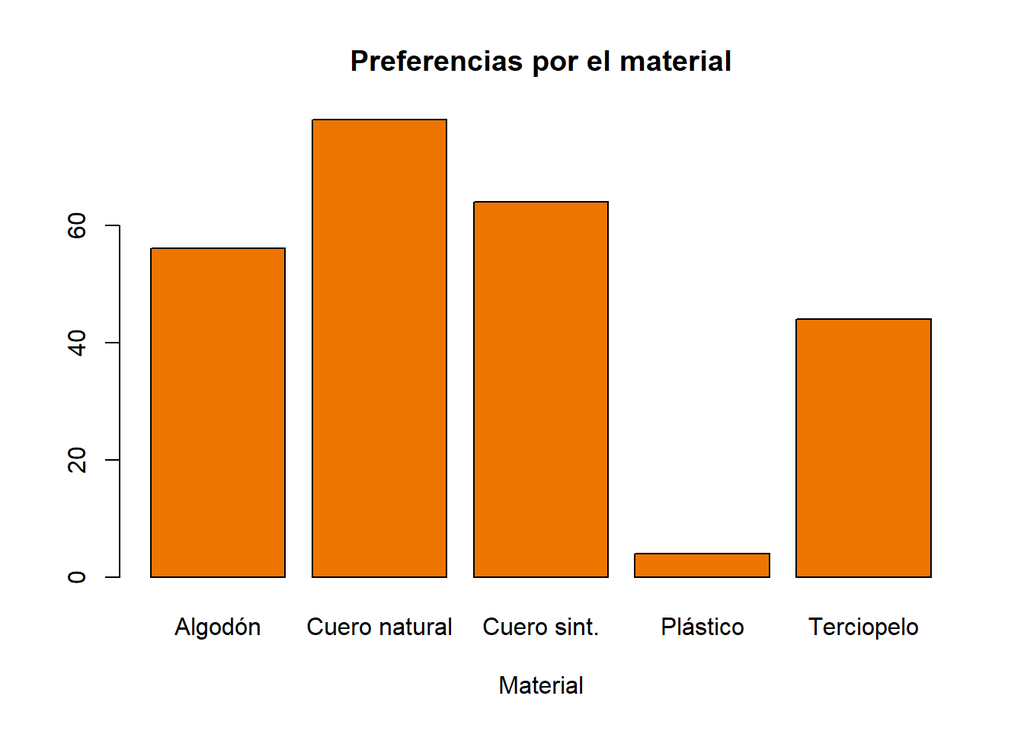

Según los datos rescatados, la población estudiantil de UTEC, en su mayoría prefiere los asientos de cuero tanto sintético como natural, siendo este último el de mayor preferencia. Asimismo, la atracción por los asientos de plástico es casi nula.

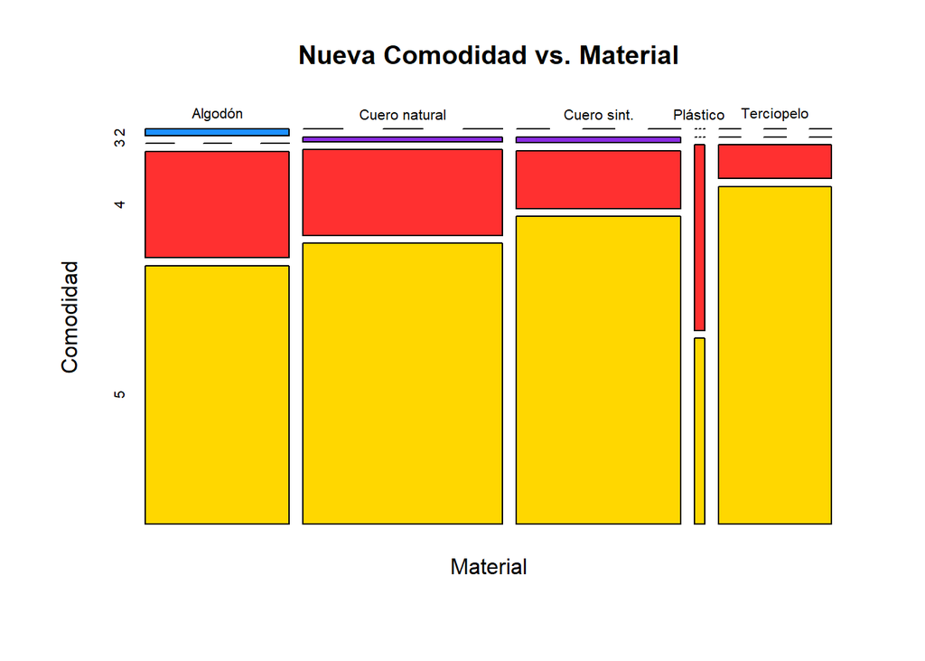

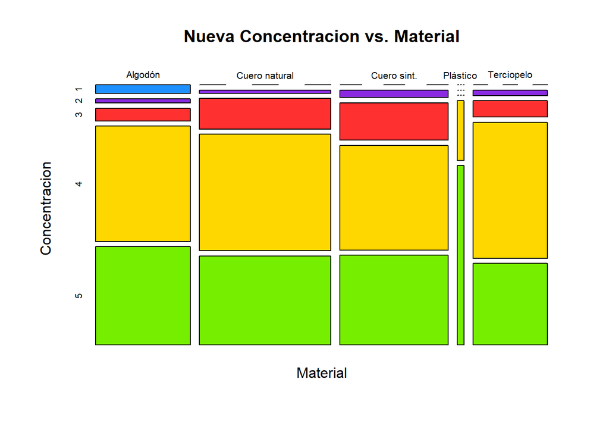

Como estaba previsto, con estos nuevos materiales, la comodidad y concentración de los estudiantes aumentaría con notoriedad. Por otro lado, como se ve en las siguientes tablas hubo un 12.67% de los que permanecieron con la misma comodidad o concentración. Sin embargo, ninguno de estos disminuyó su nivel de comodidad o concentración. Nuestra hipótesis sería, que las sillas al tener todas estas características proporcionarán mayor comodidad y por ende, mejor concentración en los estudiantes.

| Codigo | Comodidad | NewComodidad |
| --- | --- | --- |
| 2021 | 5 | 5 |
| 2020 | 5 | 5 |
| 2017 | 4 | 4 |
| 2018 | 4 | 4 |
| 2020 | 5 | 5 |
| 2020 | 5 | 5 |
| 2020 | 4 | 4 |
| 2019 | 5 | 5 |
| 2015 | 5 | 5 |
| 2021 | 5 | 5 |

[output cut: 22 more lines]

| Codigo | Concentracion | NewConcentracion |
| --- | --- | --- |
| 2020 | 4 | 4 |
| 2020 | 4 | 4 |
| 2020 | 3 | 3 |
| 2019 | 4 | 4 |
| 2020 | 4 | 4 |
| 2020 | 4 | 4 |
| 2017 | 4 | 4 |
| 2020 | 1 | 1 |
| 2019 | 4 | 4 |
| 2020 | 3 | 3 |

[output cut: 35 more lines]

| Codigo | Comodidad | Concentracion | NewComodidad | NewConcentracion |
| --- | --- | --- | --- | --- |
| 2015 | 5 | 5 | 5 | 5 |
| 2021 | 5 | 4 | 5 | 4 |
| 2021 | 5 | 4 | 5 | 4 |
| 2020 | 5 | 4 | 5 | 4 |
| 2020 | 5 | 3 | 5 | 3 |
| 2020 | 5 | 5 | 5 | 5 |
| 2020 | 5 | 3 | 5 | 3 |
| 2019 | 5 | 4 | 5 | 4 |
| 2020 | 5 | 4 | 5 | 4 |
| 2019 | 5 | 4 | 5 | 4 |

[output cut: 2 more lines]

# **RELACIONES ENTRE VARIABLES NUMÉRICAS E HIPÓTESIS**

###### Para formar relaciones entre nuestras variables, usaremos como referencia una imagen del canon de las proporciones del cuerpo humano:

- **Usamos el siguiente video:** https://youtu.be/0C563bph4-M

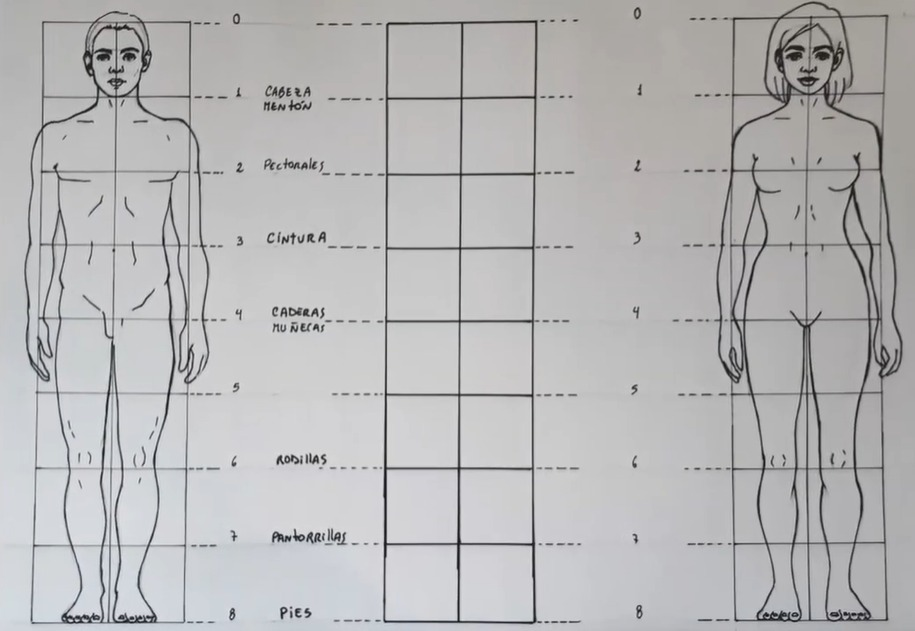

En la siguientes líneas de código estamos creando dos nuevas variables numéricas: profundidad del asiento y largo del espaldar de una silla, haciendo uso del canon de proporciones del cuerpo humano.

- Para el largo del espaldar dividimos la estatura de la persona entre 8 (por los cuadrantes señalados en la imagen) y lo multiplicamos por 2.7 de los cuadrantes, debido a que abarca aproximadamente la extensión de la cintura de una persona hasta sus omóplatos.

```r
#agregando la variable altura_espaldar
DF<-mutate(DF, Altura_E = round((Estatura/8)*2.7,6))
```

- Para la profundidad del asiento realizamos el mismo procedimiento, con la excepción de que lo multiplicamos por 2, ya que la extensión del húmero de una persona equivalía a esos 2 cuadrantes según el canon de proporciones humanas.

```r
#agregando la variable profundidad_asiento
DF<-mutate(DF, Profundidad_A = round((Estatura/8)*2,6))
```

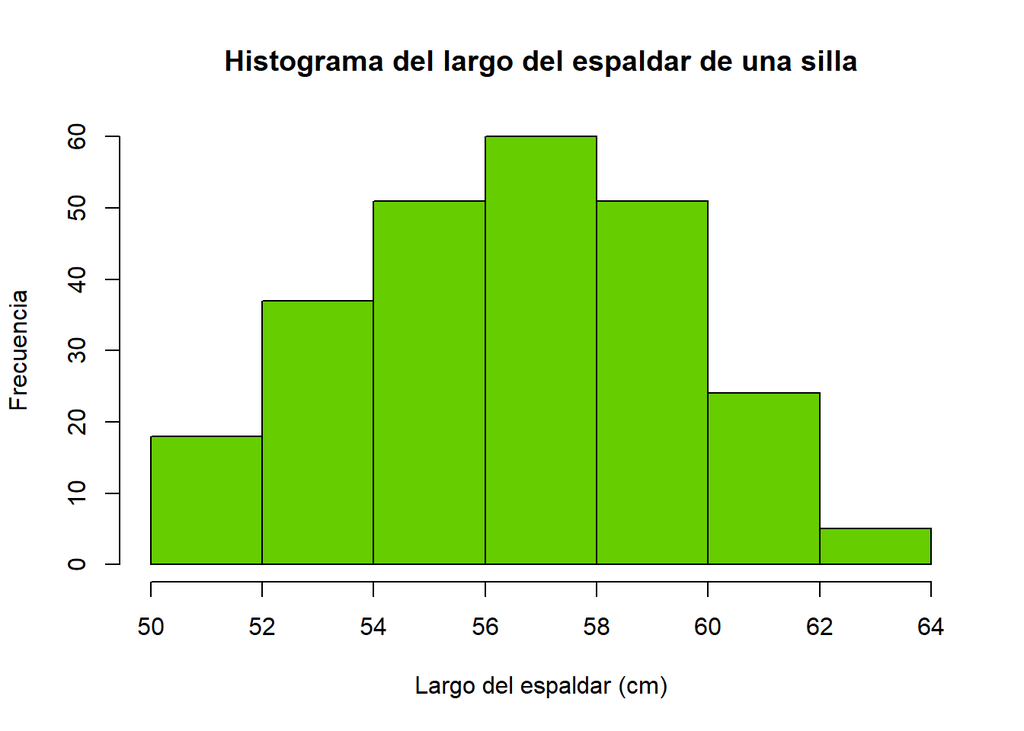

```r
hist(DF$Altura_E,main="Histograma del largo del espaldar de una silla",xlab="Largo del espaldar (cm)",ylab="Frecuencia",col="chartreuse3")
```

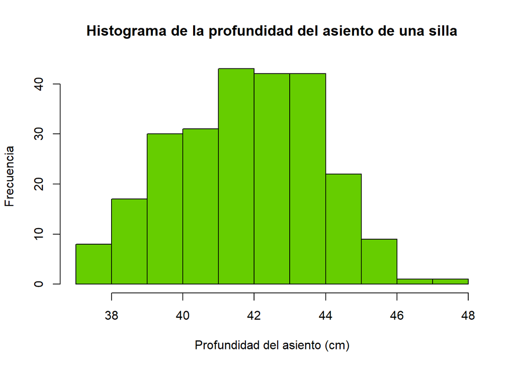

```r
hist(DF$Profundidad_A,main="Histograma de la profundidad del asiento de una silla",xlab="Profundidad del asiento (cm)",ylab="Frecuencia",col="chartreuse3",breaks = 10)
```

```r
#agregando la variable presión ejercida
DF<-mutate(DF, Presión = round((Peso*9.81/(Profundidad_A*Profundidad_A/10000))*0.001,4))
```

```r
#agregando la variable IMC
DF<-mutate(DF, IMC = round((Peso/(Estatura*Estatura/10000)),3))
```

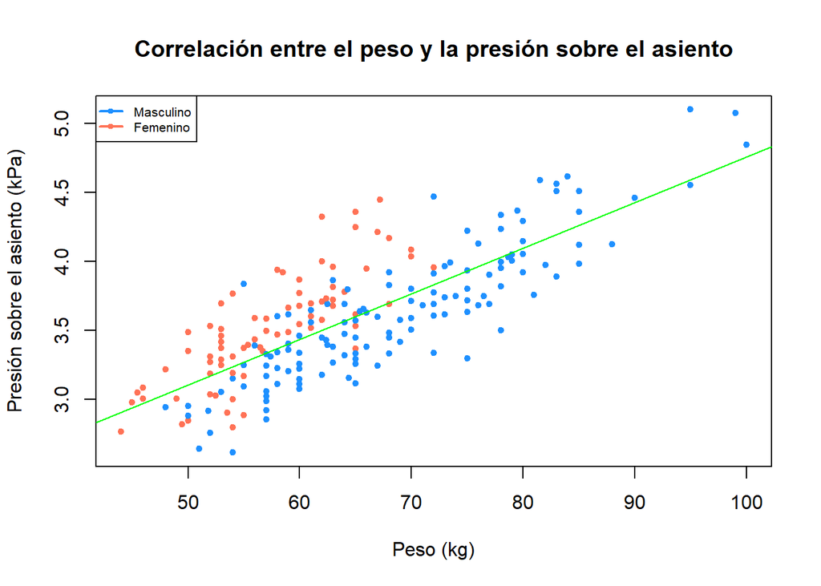

```r
plot(DF$Peso,DF$Presión,pch=20,xlab="Peso (kg)",ylab="Presión sobre el asiento (kPa)",main="Correlación entre el peso y la presión sobre el asiento",col=ifelse(DF$Sexo=="Femenino","coral1","dodgerblue1"))
abline(lm(DF$Presión~DF$Peso), col="green")
legend("topleft",legend=c("Masculino","Femenino"),pch=20,col=c("dodgerblue1","coral1"),lwd=2,cex=0.65)
```

```r
cov(DF$IMC,DF$Peso,use="complete.obs")
```

```
## [1] 23.04046
```

```r
cor(DF$IMC,DF$Peso,use="complete.obs")
```

```
## [1] 0.7898769
```

Con la ayuda del gráfico “Correlación entre el peso y la presión sobre el asiento” decidimos plantear la siguiente hipótesis a partir de la tendencia que se aprecia en el gráfico: conforme el peso del estudiante incrementa, la presión que debe soportar la silla es mayor. Por ende, un fabricante de sillas debería tener en consideración el material del que estará hecho la silla, ya que la fuerza que ejercerá el estudiante sobre la misma es considerable conforme su peso aumente.

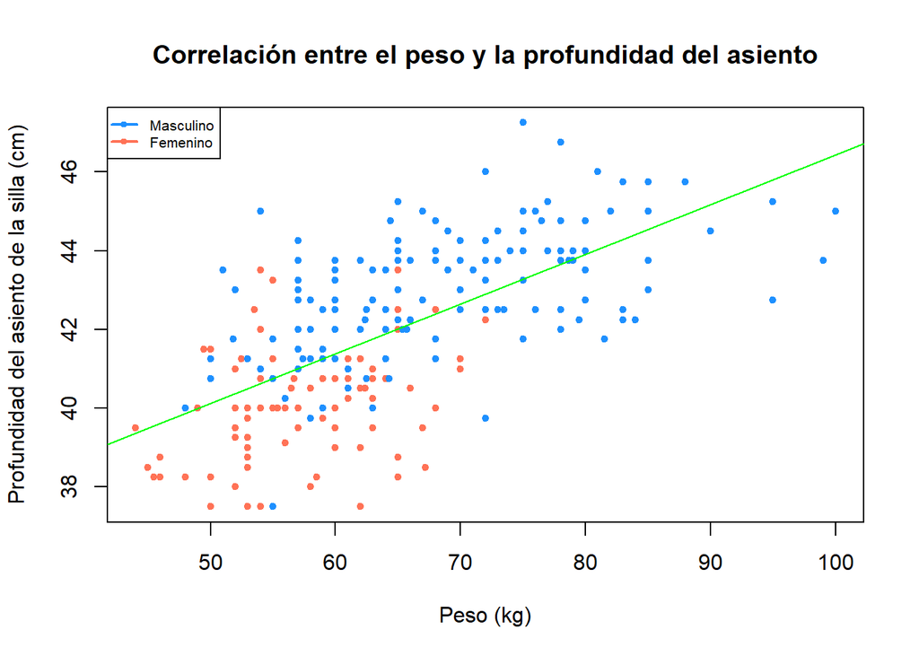

```r
plot(DF$Peso,DF$Profundidad_A,pch=20,xlab="Peso (kg)",ylab="Profundidad del asiento de la silla (cm)",col=ifelse(DF$Sexo=="Femenino","coral1","dodgerblue1"),main="Correlación entre el peso y la profundidad del asiento")
legend("topleft",legend=c("Masculino","Femenino"),pch=20,col=c("dodgerblue1","coral1"),lwd=2,cex=0.65)
abline(lm(DF$Profundidad_A~DF$Peso), col="green")
```

```r
cov(DF$Peso,DF$Profundidad_A,use="complete.obs")
```

```
## [1] 13.78208
```

```r
cor(DF$Peso,DF$Profundidad_A,use="complete.obs")
```

```
## [1] 0.6400245
```

Del gráfico “Correlación entre el peso y la profundidad del asiento” se planteó la siguiente hipótesis a partir de la tendencia que se observa en la misma: conforme aumenta el peso del estudiante, la profundidad del asiento incrementaría en paralelo. Esto podría deberse indirectamente a que mientras el peso incrementa, probablemente la masa corporal del estudiante será mayor; por ende, el estudiante necesitaría un asiento de mayor área para que le proporcione un mayor nivel de comodidad.

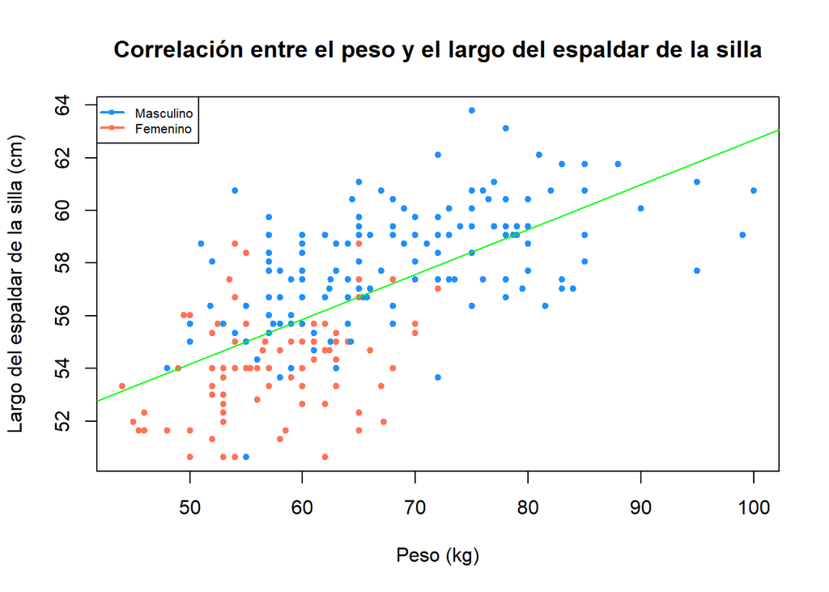

```r
plot(DF$Peso,DF$Altura_E,pch=20,xlab="Peso (kg)",ylab="Largo del espaldar de la silla (cm)",col=ifelse(DF$Sexo=="Femenino","coral1","dodgerblue1"),main="Correlación entre el peso y el largo del espaldar de la silla")
legend("topleft",legend=c("Masculino","Femenino"),pch=20,col=c("dodgerblue1","coral1"),lwd=2,cex=0.65)
abline(lm(DF$Altura_E~DF$Peso), col="green")
```

```r
cov(DF$Peso,DF$Altura_E,use="complete.obs")
```

```
## [1] 18.60581
```